# Signs & Gestures (study2children)

Adam Stone, PhD

02-23-2018

# Importing Summary Data

We’re going to load the summary data from Tobii that shows looking duration for each AOI and each trial. This is fine because there’s only one repetition of each trial, so we can just use that output as it is. Other studies have more than one repetition, which Tobii collapses together when making summary data (and which we don’t want), so we prefer to use raw data for those to calculate looking durations.

```r
data <- read_csv("../signgesturedata/dynamicaois.csv") %>%
  clean_names() %>%
  gather(stimulus, sec, gesta_fw_belly:signd_er_rightfacetop) %>%
  select(-c(sum, age, agegroup))
```

[output not shown]

## Swapping in re-aligned data

Now we are going to swap in/out data for those who have been re-aligned. For comparison let’s just pull the mean percent across everybody.

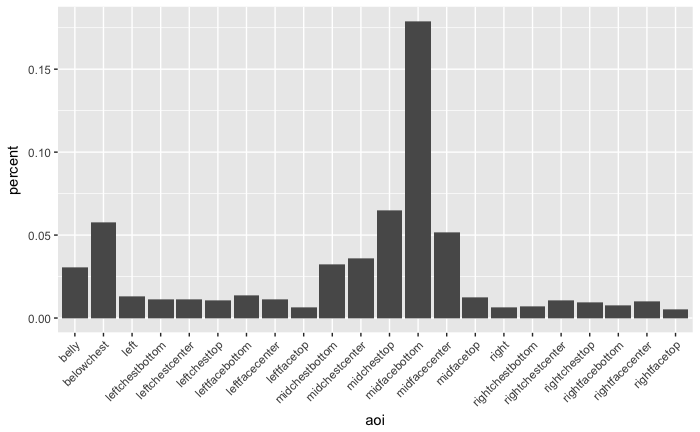

```r
ggplot(data, aes(x = aoi, y = percent)) + stat_summary_bin(fun.y = "mean", geom = "bar") + theme(axis.text.x = element_text(angle=45, hjust = 1))
```

### Rowan

Let’s see Rowan’s original, mis-aligned data

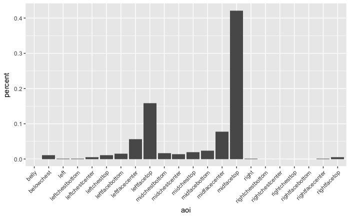

```r
rowan <- data %>% filter(name == "Rowan_6m")
ggplot(rowan, aes(x = aoi, y = percent)) + stat_summary_bin(fun.y = "mean", geom = "bar") + theme(axis.text.x = element_text(angle=45, hjust = 1))
```

Now let’s see Rowan’s new data.

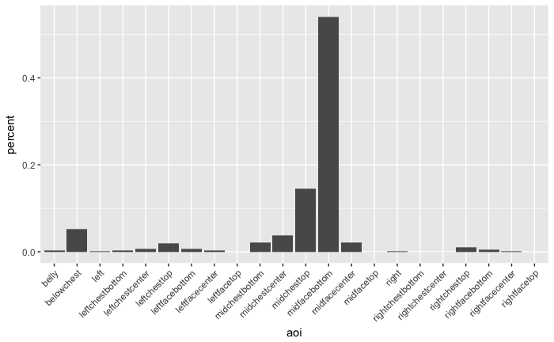

```r
# Clean up the new data
rowan_new <- read_tsv("../signgesturedata/rowan grp 2 adjusted AOIs moved up and slightly to the left.txt") %>% clean_names() %>%
  rename(name = x1) %>%
  select(-c(age:signer)) %>%
  gather(aoi, sec, 2:353) %>%
  na_if("-") %>%
  mutate(sec = replace_na(sec, 0)) %>%
  mutate(aoi = str_remove_all(aoi, "total_fixation_duration_"),
         aoi = str_remove_all(aoi, "_xvid_xvid_avi"),
         aoi = str_remove_all(aoi, "_sum")) %>%
  separate(aoi, into = c("media","direction","aoi","new")) %>%
  filter(!is.na(new)) %>%
  select(-c(new))
# Add correct labels and calculate percentages
rowan_new <- rowan_new %>%
  mutate(media = case_when(
    media == "gesturea" ~ "gesta",
    media == "gestureb" ~ "gestb",
    media == "gesturec" ~ "gestc",
    media == "gestured" ~ "gestd",
    TRUE ~ media
  )) %>%
  mutate(video = str_sub(media, 5, 6),
         type = str_sub(media, 0, 4)) %>%
  mutate(video = case_when(
    type == "gest" & video == "a" ~ "e",
    type == "gest" & video == "b" ~ "f",
    type == "gest" & video == "c" ~ "g",
    type == "gest" & video == "d" ~ "h",
    TRUE ~ video
  )) %>%
  mutate(direction = case_when(
    direction == "fw" ~ "forward",
    direction == "er" ~ "reversed"
  )) %>%
  left_join(lengths, by = "media") %>%
  mutate(sec = as.numeric(sec),
         percent = sec/length)
ggplot(rowan_new, aes(x = aoi, y = percent)) + stat_summary_bin(fun.y = "mean", geom = "bar") + theme(axis.text.x = element_text(angle=45, hjust = 1))
```